# Análise Exploratória de Dados Socioeconômicos

CLAUDER

2022-05-12

```r
library(dplyr)
```

```r
library(ggplot2)
```

```r
dados <- read.csv("dataset.csv")
```

```r
head(dados)
```

```
##   ï..Country.name year Life.Ladder Log.GDP.per.capita Social.support
## 1     Afghanistan 2008       3.724              7.370          0.451
## 2     Afghanistan 2009       4.402              7.540          0.552
## 3     Afghanistan 2010       4.758              7.647          0.539
## 4     Afghanistan 2011       3.832              7.620          0.521
## 5     Afghanistan 2012       3.783              7.705          0.521
## 6     Afghanistan 2013       3.572              7.725          0.484
##   Healthy.life.expectancy.at.birth Freedom.to.make.life.choices Generosity
## 1                            50.80                        0.718      0.168
## 2                            51.20                        0.679      0.190
## 3                            51.60                        0.600      0.121
## 4                            51.92                        0.496      0.162
## 5                            52.24                        0.531      0.236
## 6                            52.56                        0.578      0.061
##   Perceptions.of.corruption Positive.affect Negative.affect
## 1                     0.882           0.518           0.258
## 2                     0.850           0.584           0.237
## 3                     0.707           0.618           0.275
## 4                     0.731           0.611           0.267
## 5                     0.776           0.710           0.268
## 6                     0.823           0.621           0.273
```

```r
dim(dados)
```

```
## [1] 1949   11
```

```r
View(dados)
```

```r
summary(dados)
```

```
##  ï..Country.name         year       Life.Ladder    Log.GDP.per.capita
##  Length:1949        Min.   :2005   Min.   :2.375   Min.   : 6.635
##  Class :character   1st Qu.:2010   1st Qu.:4.640   1st Qu.: 8.464
##  Mode  :character   Median :2013   Median :5.386   Median : 9.460
##                     Mean   :2013   Mean   :5.467   Mean   : 9.368
##                     3rd Qu.:2017   3rd Qu.:6.283   3rd Qu.:10.353
##                     Max.   :2020   Max.   :8.019   Max.   :11.648
##                                                    NA's   :36
##  Social.support   Healthy.life.expectancy.at.birth Freedom.to.make.life.choices
##  Min.   :0.2900   Min.   :32.30                    Min.   :0.2580
##  1st Qu.:0.7498   1st Qu.:58.69                    1st Qu.:0.6470
##  Median :0.8355   Median :65.20                    Median :0.7630
##  Mean   :0.8126   Mean   :63.36                    Mean   :0.7426
##  3rd Qu.:0.9050   3rd Qu.:68.59                    3rd Qu.:0.8560
##  Max.   :0.9870   Max.   :77.10                    Max.   :0.9850
##  NA's   :13       NA's   :55                       NA's   :32
##    Generosity      Perceptions.of.corruption Positive.affect  Negative.affect
##  Min.   :-0.3350   Min.   :0.0350            Min.   :0.3220   Min.   :0.0830
##  1st Qu.:-0.1130   1st Qu.:0.6900            1st Qu.:0.6255   1st Qu.:0.2060
##  Median :-0.0255   Median :0.8020            Median :0.7220   Median :0.2580
##  Mean   : 0.0001   Mean   :0.7471            Mean   :0.7100   Mean   :0.2685
##  3rd Qu.: 0.0910   3rd Qu.:0.8720            3rd Qu.:0.7990   3rd Qu.:0.3200
##  Max.   : 0.6980   Max.   :0.9830            Max.   :0.9440   Max.   :0.7050
##  NA's   :89        NA's   :110               NA's   :22       NA's   :16
```

#### Analise e Exploratória dos Dados

Quantas linnhas tem casos completos

```r
complete.cases <- sum(complete.cases(dados))
complete.cases
```

```
## [1] 1708
```

Quantas Linhas tem Casos INcompletos

```r
not_complete_cases <- sum(!complete.cases(dados))
not_complete_cases
```

```
## [1] 241
```

Qual o percentual de Dados Incompletos

```r
percentual <- (not_complete_cases / complete.cases) * 100
percentual
```

```
## [1] 14.11007
```

Remover os objetos anteriores para liberar memória RAm

```r
rm(complete.cases)
rm(not_complete_cases)
```

NOmes das colunas

```r
colnames(dados)
```

```
##  [1] "ï..Country.name"                  "year"
##  [3] "Life.Ladder"                      "Log.GDP.per.capita"
##  [5] "Social.support"                   "Healthy.life.expectancy.at.birth"
##  [7] "Freedom.to.make.life.choices"     "Generosity"
##  [9] "Perceptions.of.corruption"        "Positive.affect"
## [11] "Negative.affect"
```

Gravar os nomes das colunas em um Vetor

```r
myColumns <-  colnames(dados)
myColumns
```

```
##  [1] "ï..Country.name"                  "year"
##  [3] "Life.Ladder"                      "Log.GDP.per.capita"
##  [5] "Social.support"                   "Healthy.life.expectancy.at.birth"
##  [7] "Freedom.to.make.life.choices"     "Generosity"
##  [9] "Perceptions.of.corruption"        "Positive.affect"
## [11] "Negative.affect"
```

```r
# Aideia é mudar cada elemento do vetor, colocando em português

myColumns[1] <- "NomePais"
myColumns[2] <- "Ano"
myColumns[3] <- "IndicadorNivelVida"
myColumns[4] <- "PIB_Per_Capita"
myColumns[5] <- "SuporteSocial"
myColumns[6] <- "ExpectativaVida"
myColumns[7] <- "IndicadorLiberdade"
myColumns[8] <- "IndicadorGenerosidade"
myColumns[9] <- "IndicadorCorrupcao"
myColumns[10] <- "IndicadorEmocoesPositivas"
myColumns[11] <- "IndicadorEmocoesNegativas"
```

Verificar o Resultado

```r
myColumns
```

```
##  [1] "NomePais"                  "Ano"
##  [3] "IndicadorNivelVida"        "PIB_Per_Capita"
##  [5] "SuporteSocial"             "ExpectativaVida"
##  [7] "IndicadorLiberdade"        "IndicadorGenerosidade"
##  [9] "IndicadorCorrupcao"        "IndicadorEmocoesPositivas"
## [11] "IndicadorEmocoesNegativas"
```

Atribui os novos nomes de colunas ao dataframe

```r
colnames(dados) <- myColumns
rm(myColumns)
```

Verificar quantos países form aincluidas na coleta de dados

```r
length(unique(dados$NomePais))
```

```
## [1] 166
```

Listar os países único e grava i resultado (antes de remover registros com valores NAs)

```r
list_Countries <- unique(dados$NomePais)
list_Countries
```

```
##   [1] "Afghanistan"               "Albania"
##   [3] "Algeria"                   "Angola"
##   [5] "Argentina"                 "Armenia"
##   [7] "Australia"                 "Austria"
##   [9] "Azerbaijan"                "Bahrain"
##  [11] "Bangladesh"                "Belarus"
##  [13] "Belgium"                   "Belize"
##  [15] "Benin"                     "Bhutan"
##  [17] "Bolivia"                   "Bosnia and Herzegovina"
##  [19] "Botswana"                  "Brazil"
##  [21] "Bulgaria"                  "Burkina Faso"
##  [23] "Burundi"                   "Cambodia"
##  [25] "Cameroon"                  "Canada"
##  [27] "Central African Republic"  "Chad"
##  [29] "Chile"                     "China"
```

[output cut: 68 more lines]

Eliminar valores NAs

```r
dados <- na.omit(dados)
```

Dimensoes

```r
dim(dados)
```

```
## [1] 1708   11
```

lista de países após remver valores NAs

```r
list_of_countrios_without <- unique(dados$NomePais)
list_of_countrios_without
```

```
##   [1] "Afghanistan"              "Albania"
##   [3] "Algeria"                  "Angola"
##   [5] "Argentina"                "Armenia"
##   [7] "Australia"                "Austria"
##   [9] "Azerbaijan"               "Bahrain"
##  [11] "Bangladesh"               "Belarus"
##  [13] "Belgium"                  "Belize"
##  [15] "Benin"                    "Bhutan"
##  [17] "Bolivia"                  "Bosnia and Herzegovina"
##  [19] "Botswana"                 "Brazil"
##  [21] "Bulgaria"                 "Burkina Faso"
##  [23] "Burundi"                  "Cambodia"
##  [25] "Cameroon"                 "Canada"
##  [27] "Central African Republic" "Chad"
##  [29] "Chile"                    "Colombia"
```

[output cut: 63 more lines]

Dimensões

```r
dim(dados)
```

```
## [1] 1708   11
```

Verificar quais anos estão presente nos dados

```r
anos <- unique(dados$Ano)
anos
```

```
##  [1] 2008 2009 2010 2011 2012 2013 2014 2015 2016 2017 2018 2019 2007 2020 2006
## [16] 2005
```

```r
range(anos)
```

```
## [1] 2005 2020
```

```r
length(unique(dados$Ano))
```

```
## [1] 16
```

```r
rm(anos)
```

Número de Registros por Ano

```r
table(dados$Ano)
```

```
##
## 2005 2006 2007 2008 2009 2010 2011 2012 2013 2014 2015 2016 2017 2018 2019 2020
##    1   74   94  101  106  112  132  121  124  127  127  124  132  126  126   81
```

Temos a quantidade de registro por ano.

#### Remover os anos com menor contribuição (menor Volume por ano)

```r
dados_por_anos <- dados[dados$Ano!=2005 & dados$Ano!=2006 & dados$Ano!=2007 & dados$Ano!=2020,]
```

Número de registro por ano

```r
table(dados_por_anos$Ano)
```

```
##
## 2008 2009 2010 2011 2012 2013 2014 2015 2016 2017 2018 2019
##  101  106  112  132  121  124  127  127  124  132  126  126
```

Quantidade de registros por ano de 2008 a 2019

#### Extraindo as variaveis númericas

```r
numeric_variable_list <- sapply(dados, is.numeric)


numeric_data <- dados[numeric_variable_list]
```

#### Matriz de Corelaçaõ

```r
cor(numeric_data)
```

```
##                                   Ano IndicadorNivelVida PIB_Per_Capita
## Ano                        1.00000000         0.06408027     0.09206425
## IndicadorNivelVida         0.06408027         1.00000000     0.79284840
## PIB_Per_Capita             0.09206425         0.79284840     1.00000000
## SuporteSocial              0.01035333         0.71321105     0.70597215
## ExpectativaVida            0.18306796         0.75469722     0.86034469
## IndicadorLiberdade         0.25393021         0.52508913     0.35318178
## IndicadorGenerosidade     -0.03553778         0.18275770    -0.02456456
## IndicadorCorrupcao        -0.09885100        -0.44815657    -0.34346781
## IndicadorEmocoesPositivas  0.01846462         0.53309173     0.29647303
## IndicadorEmocoesNegativas  0.20513026        -0.30046627    -0.22480625
##                           SuporteSocial ExpectativaVida IndicadorLiberdade
## Ano                          0.01035333      0.18306796          0.2539302
## IndicadorNivelVida           0.71321105      0.75469722          0.5250891
## PIB_Per_Capita               0.70597215      0.86034469          0.3531818
## SuporteSocial                1.00000000      0.61744641          0.4117193
## ExpectativaVida              0.61744641      1.00000000          0.3848287
## IndicadorLiberdade           0.41171930      0.38482866          1.0000000
## IndicadorGenerosidade        0.05613060      0.01818798          0.3263129
## IndicadorCorrupcao          -0.22685476     -0.33499041         -0.4880720
## IndicadorEmocoesPositivas    0.44996871      0.31888568          0.6116727
## IndicadorEmocoesNegativas   -0.41535800     -0.14301375         -0.2673488
##                           IndicadorGenerosidade IndicadorCorrupcao
## Ano                                 -0.03553778         -0.0988510
## IndicadorNivelVida                   0.18275770         -0.4481566
## PIB_Per_Capita                      -0.02456456         -0.3434678
## SuporteSocial                        0.05613060         -0.2268548
## ExpectativaVida                      0.01818798         -0.3349904
## IndicadorLiberdade                   0.32631287         -0.4880720
## IndicadorGenerosidade                1.00000000         -0.2884672
## IndicadorCorrupcao                  -0.28846724          1.0000000
## IndicadorEmocoesPositivas            0.37152999         -0.3013833
## IndicadorEmocoesNegativas           -0.09440134          0.2765176
##                           IndicadorEmocoesPositivas IndicadorEmocoesNegativas
## Ano                                      0.01846462                0.20513026
## IndicadorNivelVida                       0.53309173               -0.30046627
## PIB_Per_Capita                           0.29647303               -0.22480625
## SuporteSocial                            0.44996871               -0.41535800
## ExpectativaVida                          0.31888568               -0.14301375
## IndicadorLiberdade                       0.61167275               -0.26734883
## IndicadorGenerosidade                    0.37152999               -0.09440134
## IndicadorCorrupcao                      -0.30138327                0.27651758
## IndicadorEmocoesPositivas                1.00000000               -0.36036107
## IndicadorEmocoesNegativas               -0.36036107                1.00000000
```

Plot de Correlação

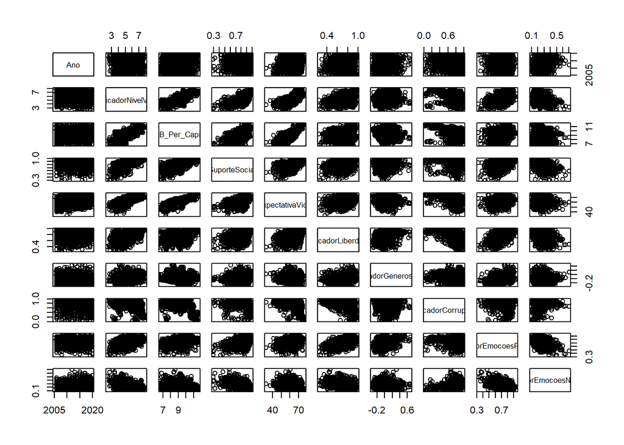

```r
pairs(numeric_data)
```

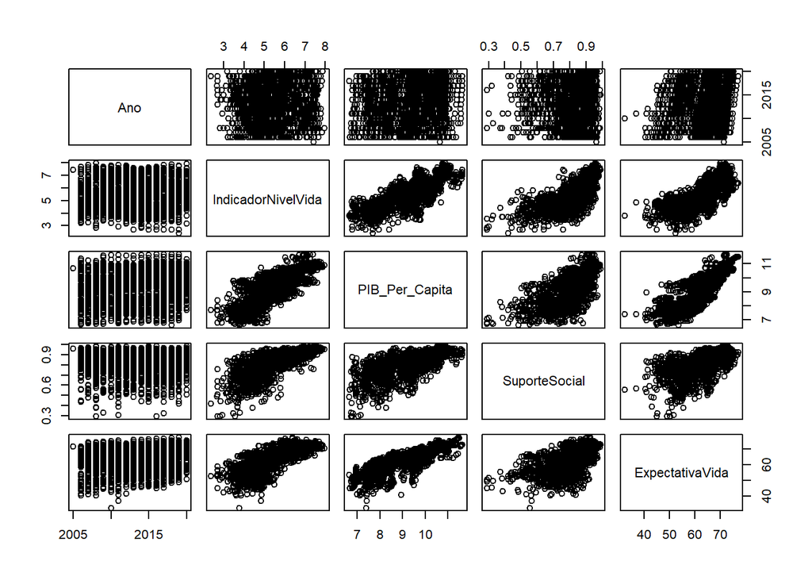

```r
pairs(numeric_data[1:5],labels = colnames(numeric_data)[1:5])
```

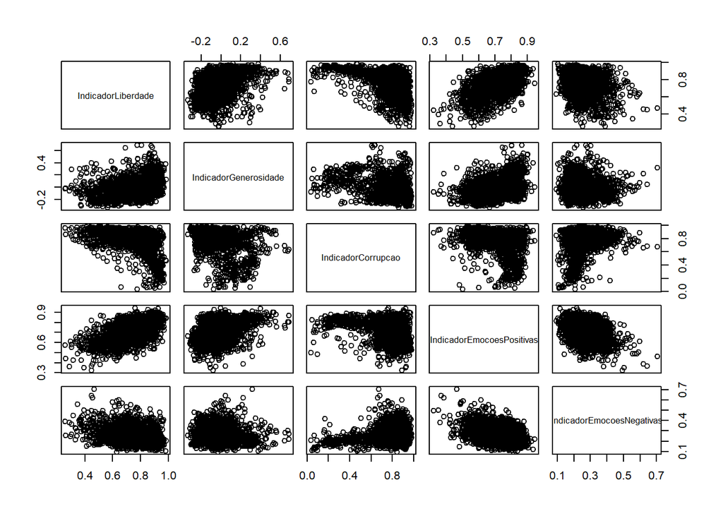

```r
pairs(numeric_data[6:10],labels = colnames(numeric_data)[6:10])
```

##### Análise Exploratória dos Dados - Resposta às Perguntas de Negócio

###### Organização dos Dados

Vamos realizar a análise considerando a média de indicadores por país. Calculamos as médias fazendo agrupamento por indicador e concatenamos os dataframes resultantes.

Visualiza os dados

Agrupando os dados e calculando média por país

```r
pib_per_capita_pais_media <- dados %>%
  group_by(NomePais) %>%
  summarize(PIB_Per_Capita = mean(PIB_Per_Capita))
```

Agrupando os dados e calculando média por país

```r
suporte_social_pais_media <- dados %>%
  group_by(NomePais) %>%
  summarize(SuporteSocial = mean(SuporteSocial))
```

Merge dos dataframes

```r
df_medias <- merge(pib_per_capita_pais_media, suporte_social_pais_media)


#Perdemos a coluna tempo.. no projeto a coluna tempo não faz diferença.
#Mas é bom sempre terpor perto
```

```r
View(df_medias)
```

Remover o que não estiver mais usando

```r
rm(pib_per_capita_pais_media)
rm(suporte_social_pais_media)
```

Agrupando os dados e calculando a média por país.

```r
ind_nivel_vida_pais_media <- dados %>%
  group_by(NomePais) %>%
  summarize(IndicadorNivelVida = mean(IndicadorNivelVida))
```

Merge

```r
df_medias <- merge(df_medias, ind_nivel_vida_pais_media)
View(df_medias)
rm(ind_nivel_vida_pais_media)
```

Agrupando os dados e calculando média por país

```r
expectativa_vida_pais_media <- dados %>%
  group_by(NomePais) %>%
  summarize(ExpectativaVida = mean(ExpectativaVida))
```

# Merge

```r
df_medias <- merge(df_medias, expectativa_vida_pais_media)
View(df_medias)
rm(expectativa_vida_pais_media)
```

Agrupando os dados e calculando média por país

```r
ind_liberdade_pais_media <- dados %>%
  group_by(NomePais) %>%
  summarize(IndicadorLiberdade = mean(IndicadorLiberdade))

df_medias <- merge(df_medias, ind_liberdade_pais_media)
View(df_medias)
rm(ind_liberdade_pais_media)
```

Agrupando os dados e calculando média por país

```r
ind_generosidade_pais_media <- dados %>%
  group_by(NomePais) %>%
  summarize(IndicadorGenerosidade = mean(IndicadorGenerosidade))
```

Merge

```r
df_medias <- merge(df_medias, ind_generosidade_pais_media)
View(df_medias)
rm(ind_generosidade_pais_media)
```

Agrupando os dados e calculando média por país

```r
ind_corrupcao_pais_media <- dados %>%
  group_by(NomePais) %>%
  summarize(IndicadorCorrupcao = mean(IndicadorCorrupcao))
```

Merge

```r
df_medias <- merge(df_medias, ind_corrupcao_pais_media)
View(df_medias)
rm(ind_corrupcao_pais_media)
```

Agrupando os dados e calculando média por país

```r
ind_pos_pais_media <- dados %>%
  group_by(NomePais) %>%
  summarize(IndicadorEmocoesPositivas = mean(IndicadorEmocoesPositivas))
```

# Merge

```r
df_medias <- merge(df_medias, ind_pos_pais_media)
View(df_medias)
rm(ind_pos_pais_media)
```

Agrupando os dados e calculando média por país

```r
ind_neg_pais_media <- dados %>%
  group_by(NomePais) %>%
  summarize(IndicadorEmocoesNegativas = mean(IndicadorEmocoesNegativas))
```

Merge

```r
df_medias <- merge(df_medias, ind_neg_pais_media)
View(df_medias)
rm(ind_neg_pais_media)
dim(df_medias)
```

```
## [1] 155  10
```

Respsta das perguntas de negocio

##### Pergunta 1

O aumento do PIB per capita de um país afeta positivamente a expectativa de vida dos cidadãos ao nascer?

Qual a correlação entre essas duas variáveis?

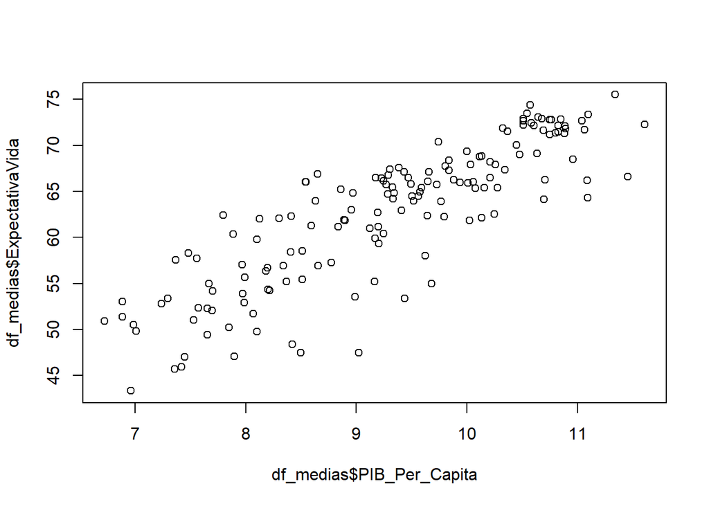

```r
plot(df_medias$PIB_Per_Capita, df_medias$ExpectativaVida)
```

Correlação:

```r
cor.test(df_medias$PIB_Per_Capita, df_medias$ExpectativaVida, method = "pearson")
```

```
##
##  Pearson's product-moment correlation
##
## data:  df_medias$PIB_Per_Capita and df_medias$ExpectativaVida
## t = 20.284, df = 153, p-value < 2.2e-16
## alternative hypothesis: true correlation is not equal to 0
## 95 percent confidence interval:
##  0.8043976 0.8914404
## sample estimates:
##       cor
## 0.8537768
```

#### Pergunta 2

Existe uma correlação entre a escala de vida e a conscientização do público em geral sobre a corrupção nos negócios e no governo?

Qual a correlação entre essas duas variáveis?

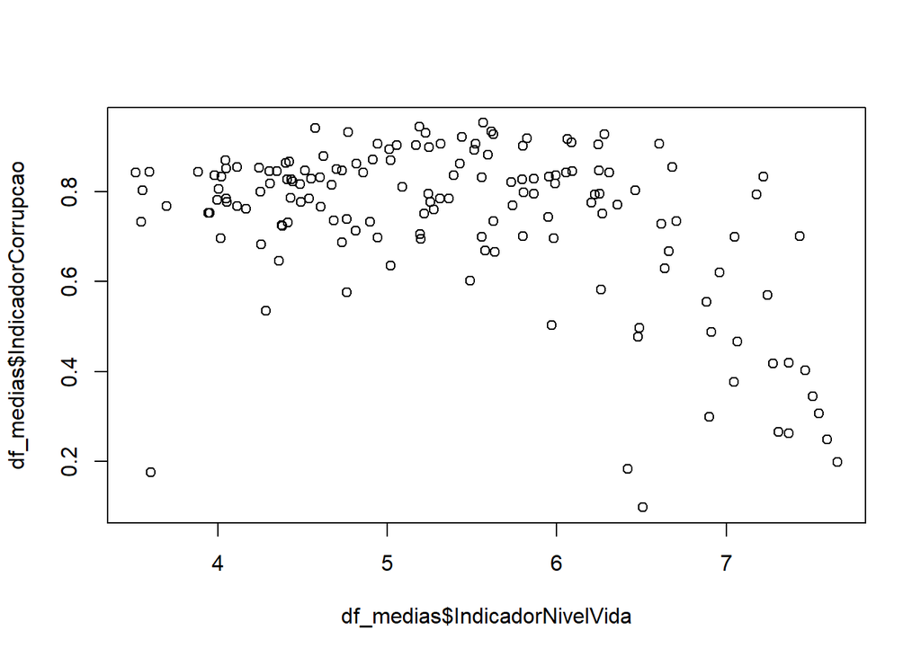

```r
plot(df_medias$IndicadorNivelVida, df_medias$IndicadorCorrupcao)
```

Correlação:

```r
cor.test(df_medias$IndicadorNivelVida, df_medias$IndicadorCorrupcao, method = "pearson")
```

```
##
##  Pearson's product-moment correlation
##
## data:  df_medias$IndicadorNivelVida and df_medias$IndicadorCorrupcao
## t = -6.4831, df = 153, p-value = 1.171e-09
## alternative hypothesis: true correlation is not equal to 0
## 95 percent confidence interval:
##  -0.5794676 -0.3307878
## sample estimates:
##        cor
## -0.4642275
```

Temos uma correlação negativa, diferença de direção, aumenta uma variavel diminui a outra. Talvez não tem tanta corrupção em países desenvolvidos.

#### Pergunta 3

O aumento na escala de vida tem algum efeito na média de felicidade entre o público em geral? Qual a correlação entre essas duas variáveis?

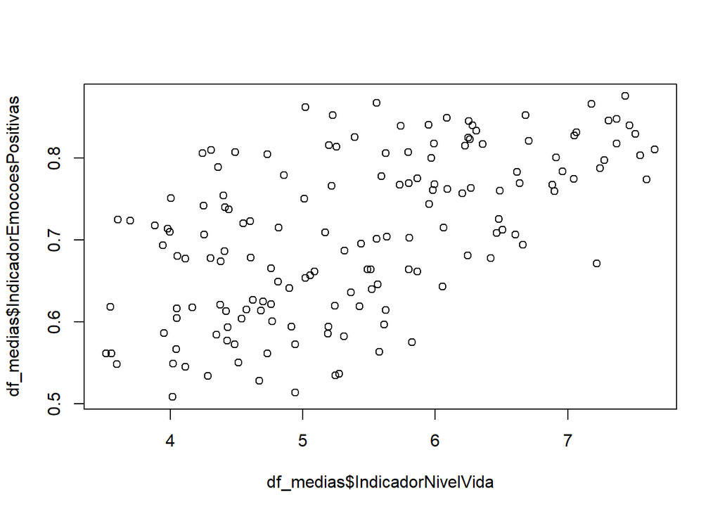

```r
plot(df_medias$IndicadorNivelVida, df_medias$IndicadorEmocoesPositivas)
```

```r
cor.test(df_medias$IndicadorNivelVida, df_medias$IndicadorEmocoesPositivas, method = "pearson")
```

```
##
##  Pearson's product-moment correlation
##
## data:  df_medias$IndicadorNivelVida and df_medias$IndicadorEmocoesPositivas
## t = 8.7567, df = 153, p-value = 3.506e-15
## alternative hypothesis: true correlation is not equal to 0
## 95 percent confidence interval:
##  0.4622592 0.6740501
## sample estimates:
##       cor
## 0.5778006
```

Felicidade é uma emoção positiva, entaão vamos usar a felicidade. Temos uma correlação positva, quanto mais aumenta a escala de vida mais elizes são as pessoas. Se a pessoa tem um bom salário se vive em um lugar bom, essa pessoa vai ter uma padrão de vida muito boa. Temos 0.57 em correlação, isso que dizer que temos uma boa correlação.

#### Pergunta 4

O país com o menor índice de suporte social tem maior percepção de corrupção em relação às empresas e ao governo no país?

Indicadores

```r
#Temos que aplicar um filtro. Esse filtro foi criado.

# Indicadores
df_medias[df_medias$SuporteSocial == min(df_medias$SuporteSocial),]#se o suporte social for igual a suporte social a virgula que dizer que eu quero todas as linhas
```

```
##                    NomePais PIB_Per_Capita SuporteSocial IndicadorNivelVida
## 27 Central African Republic          6.961        0.4024              3.515
##    ExpectativaVida IndicadorLiberdade IndicadorGenerosidade IndicadorCorrupcao
## 27          43.356             0.6804                 0.027              0.842
##    IndicadorEmocoesPositivas IndicadorEmocoesNegativas
## 27                    0.5616                    0.3914
```

```r
df1 <- df_medias[df_medias$NomePais == "Central African Republic",]
#foi criando um novo dataframe

View(df1)
df1$SuporteSocial
```

```
## [1] 0.4024
```

```r
df1$IndicadorCorrupcao
```

```
## [1] 0.842
```

```r
max(df_medias$SuporteSocial)
```

```
## [1] 0.9768571
```

```r
max(df_medias$IndicadorCorrupcao)
```

```
## [1] 0.9529167
```

Plot e Estatísticas

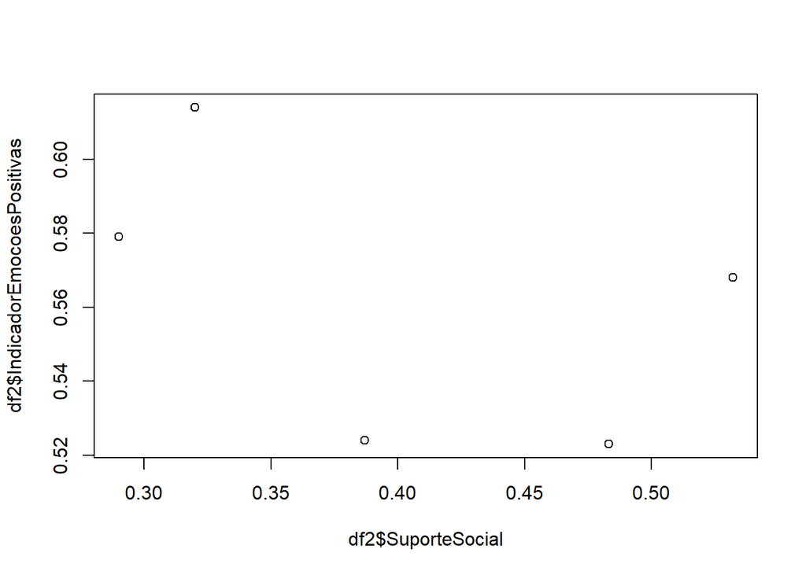

```r
#
df2 <- dados[dados$NomePais == "Central African Republic",]
View(df2)
plot(df2$SuporteSocial, df2$IndicadorEmocoesPositivas)
```

Correlação

```r
cor.test(df2$SuporteSocial, df2$IndicadorEmocoesPositivas, method = "pearson")
```

```
##
##  Pearson's product-moment correlation
##
## data:  df2$SuporteSocial and df2$IndicadorEmocoesPositivas
## t = -0.99237, df = 3, p-value = 0.3942
## alternative hypothesis: true correlation is not equal to 0
## 95 percent confidence interval:
##  -0.9588455  0.6860308
## sample estimates:
##        cor
## -0.4971288
```

#### Pergunta 5

Pessoas generosas são mais felizes?

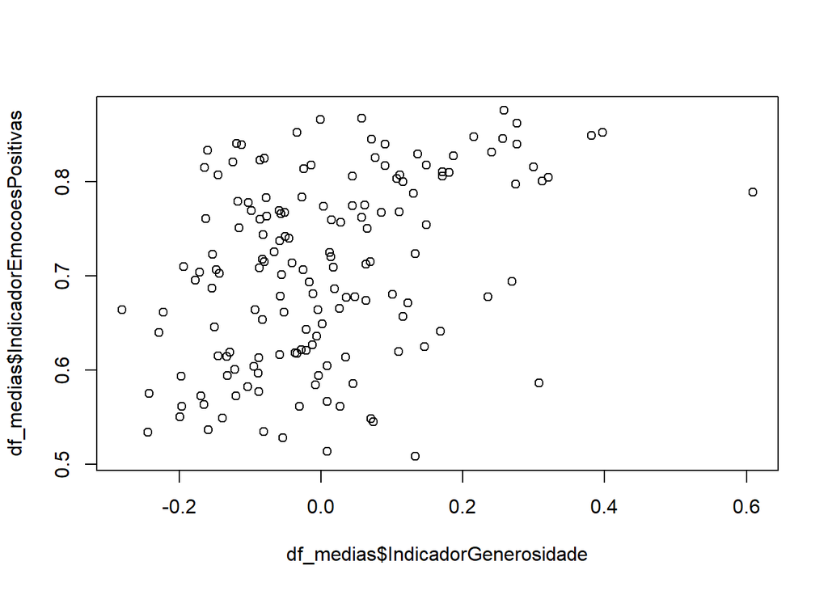

```r
plot(df_medias$IndicadorGenerosidade, df_medias$IndicadorEmocoesPositivas)
```

```r
cor.test(df_medias$IndicadorGenerosidade, df_medias$IndicadorEmocoesPositivas, method = "pearson")
```

```
##
##  Pearson's product-moment correlation
##
## data:  df_medias$IndicadorGenerosidade and df_medias$IndicadorEmocoesPositivas
## t = 5.3653, df = 153, p-value = 2.935e-07
## alternative hypothesis: true correlation is not equal to 0
## 95 percent confidence interval:
##  0.2563736 0.5227898
## sample estimates:
##       cor
## 0.3979384
```